# Análisis de actas: Elecciones nacionales 2019

> **VOLVER AL CATÁLOGO**

# 1 Análisis exploratorio

## 1.1 Base de datos en bruto

### Trep

```
Observations: 2,804,321
Variables: 28
$ Id                 <int> 1, 2, 3, 4, 5, 6, 7, 8, 9, 10, 11, 12, 13, ...
$ FechaHoraArchivo   <chr> "2019-10-20 19:40:57", "2019-10-20 19:40:57...
$ Pais               <chr> "Alemania", "Alemania", "Argentina", "Argen...
$ NumeroDepartamento <int> 61, 61, 10, 10, 10, 10, 10, 10, 10, 10, 10,...
$ Provincia          <chr> "Berlín", "Berlín", "Buenos Aires", "Buenos...
$ NumeroMunicipio    <int> 1, 1, 1, 1, 1, 1, 1, 1, 1, 1, 1, 1, 1, 1, 1...
$ Municipio          <chr> "Berlín", "Berlín", "C.A. Buenos Aires", "C...
$ Circunscripcion    <chr> "", "", "", "", "", "", "", "", "", "", "",...
$ Localidad          <chr> "Berlín", "Berlín", "C.A. Buenos Aires", "C...
$ Recinto            <chr> "Embajada", "Embajada", "Esc. Primaria Comú...
$ NumeroMesa         <int> 1001, 1002, 1003, 1004, 1005, 1006, 1007, 1...
$ CodigoMesa         <chr> "110046138042512901", "110046138042512902",...
$ Eleccion           <chr> "Presidente y Vicepresidente", "Presidente ...
$ Inscritos          <int> 237, 50, 235, 238, 237, 236, 240, 234, 234,...
$ CC                 <int> 129, 35, 52, 42, 33, 39, 53, 37, 33, 46, 50...
$ FPV                <int> 0, 0, 0, 0, 0, 0, 0, 0, 0, 0, 0, 0, 0, 0, 0...
$ MTS                <int> 3, 0, 1, 0, 0, 0, 2, 1, 0, 1, 2, 0, 1, 1, 0...
$ UCS                <int> 0, 0, 1, 0, 1, 0, 2, 0, 2, 2, 0, 1, 0, 0, 0...
$ MAS                <int> 37, 5, 59, 59, 70, 68, 73, 72, 70, 63, 58, ...
$ M21F               <int> 0, 0, 2, 2, 1, 3, 1, 1, 0, 2, 1, 0, 1, 1, 0...
$ PDC                <int> 1, 0, 9, 6, 9, 6, 7, 3, 8, 4, 6, 5, 6, 4, 0...
$ MNR                <int> 1, 0, 0, 1, 0, 1, 0, 0, 1, 0, 0, 0, 0, 0, 1...
$ PanBol             <int> 2, 0, 0, 1, 0, 0, 0, 2, 1, 1, 2, 2, 1, 1, 0...
$ Validos            <int> 173, 40, 124, 111, 114, 117, 138, 116, 115,...
$ Blancos            <int> 1, 0, 0, 0, 0, 4, 0, 1, 0, 1, 0, 0, 0, 0, 0...
$ Nulos              <int> 0, 0, 4, 3, 9, 6, 1, 3, 3, 5, 2, 2, 6, 4, 2...
$ Computada          <chr> NA, NA, NA, NA, NA, NA, NA, NA, NA, NA, NA,...
$ Departamento       <chr> "Berlín", "Berlín", "Buenos Aires", "Buenos...
```

### Computo

```
Observations: 2,832,795
Variables: 28
$ Id                 <int> 5637117, 5637118, 5637119, 5637120, 5637121...
$ FechaHoraArchivo   <chr> "2019-10-20 22:29:52", "2019-10-20 22:29:52...
$ Pais               <chr> "Bolivia", "Bolivia", "Bolivia", "Bolivia",...
$ NumeroDepartamento <int> 1, 1, 1, 1, 1, 1, 1, 1, 1, 1, 1, 1, 1, 1, 2...
$ Provincia          <chr> "Oropeza", "Oropeza", "Oropeza", "Oropeza",...
$ NumeroMunicipio    <int> 1, 1, 1, 1, 1, 1, 1, 1, 1, 1, 1, 1, 1, 1, 1...
$ Municipio          <chr> "Sucre", "Sucre", "Sucre", "Sucre", "Sucre"...
$ Circunscripcion    <chr> "", "", "", "", "", "", "", "", "", "", "",...
$ Localidad          <chr> "Sucre", "Sucre", "Sucre", "Sucre", "Sucre"...
$ Recinto            <chr> "Salon Multifuncional America", "Salon Mult...
$ NumeroMesa         <int> 10177, 10178, 10222, 10223, 10435, 10436, 1...
$ CodigoMesa         <chr> "100320127940022503", "100320127940022504",...
$ Eleccion           <chr> "Presidente y Vicepresidente", "Presidente ...
$ Inscritos          <int> 232, 232, 225, 232, 225, 228, 232, 233, 230...
$ CC                 <int> 104, 104, 162, 158, 122, 129, 88, 132, 138,...
$ FPV                <int> 3, 0, 0, 1, 2, 0, 3, 0, 0, 0, 1, 1, 0, 0, 0...
$ MTS                <int> 1, 0, 0, 0, 0, 1, 2, 1, 1, 0, 0, 1, 0, 0, 3...
$ UCS                <int> 0, 3, 1, 0, 2, 0, 0, 0, 1, 1, 1, 2, 2, 3, 0...
$ MAS                <int> 41, 51, 32, 28, 46, 35, 64, 51, 45, 32, 37,...
$ M21F               <int> 9, 6, 2, 2, 1, 1, 2, 4, 0, 4, 5, 2, 4, 2, 3...
$ PDC                <int> 26, 25, 5, 3, 13, 19, 27, 10, 13, 5, 9, 20,...
$ MNR                <int> 2, 0, 0, 0, 1, 1, 1, 0, 0, 0, 2, 0, 0, 1, 1...
$ PanBol             <int> 3, 2, 0, 0, 5, 3, 1, 0, 0, 4, 3, 0, 0, 1, 3...
$ Validos            <int> 189, 191, 202, 192, 192, 186, 188, 198, 198...
$ Blancos            <int> 5, 0, 0, 2, 4, 3, 4, 3, 0, 2, 0, 0, 1, 3, 0...
$ Nulos              <int> 9, 13, 6, 6, 5, 3, 8, 13, 7, 8, 3, 7, 21, 9...
$ Computada          <chr> "Computada", "Computada", "Computada", "Com...
$ Departamento       <chr> "Chuquisaca", "Chuquisaca", "Chuquisaca", "...
```

## 1.2 Datos de análisis

### Trep

```
Observations: 2,804,321
Variables: 16
$ fecha_hora   <dttm> 2019-10-20 19:40:57, 2019-10-20 19:40:57, 2019-1...
$ cod_mesa     <chr> "100320112000000101", "100320112000000102", "1003...
$ n_mesa       <int> 11029, 11030, 11032, 11033, 11034, 11035, 11036, ...
$ pais         <chr> "Bolivia", "Bolivia", "Bolivia", "Bolivia", "Boli...
$ departamento <chr> "Chuquisaca", "Chuquisaca", "Chuquisaca", "Chuqui...
$ provincia    <chr> "Oropeza", "Oropeza", "Oropeza", "Oropeza", "Orop...
$ municipio    <chr> "Yotala", "Yotala", "Yotala", "Yotala", "Yotala",...
$ localidad    <chr> "Yotala", "Yotala", "Yotala", "Yotala", "Yotala",...
$ recinto      <chr> "Colegio Gregorio Pacheco", "Colegio Gregorio Pac...
$ inscritos    <int> 215, 219, 219, 212, 115, 224, 222, 233, 226, 226,...
$ MAS          <int> 111, 110, 93, 88, 52, 100, 92, 83, 61, 103, 18, 7...
$ CC           <int> 46, 57, 54, 62, 26, 55, 65, 92, 102, 65, 14, 1, 1...
$ OTROS        <int> 14, 20, 22, 19, 9, 17, 27, 14, 18, 15, 1, 2, 6, 2...
$ blancos      <int> 9, 3, 7, 5, 1, 3, 1, 2, 2, 5, 1, 6, 5, 11, 13, 7,...
$ nulos        <int> 4, 2, 8, 5, 2, 12, 9, 13, 9, 12, 1, 11, 0, 13, 5,...
$ estado_acta  <chr> NA, NA, NA, NA, NA, NA, NA, NA, NA, NA, NA, NA, N...
```

### Comp

```
Observations: 2,832,795
Variables: 16
$ fecha_hora   <dttm> 2019-10-20 22:29:52, 2019-10-20 22:29:52, 2019-1...
$ cod_mesa     <chr> "100320127940011507", "100320127940011509", "1003...
$ n_mesa       <int> 10705, 10707, 10709, 10710, 10717, 10723, 10725, ...
$ pais         <chr> "Bolivia", "Bolivia", "Bolivia", "Bolivia", "Boli...
$ departamento <chr> "Chuquisaca", "Chuquisaca", "Chuquisaca", "Chuqui...
$ provincia    <chr> "Oropeza", "Oropeza", "Oropeza", "Oropeza", "Orop...
$ municipio    <chr> "Sucre", "Sucre", "Sucre", "Sucre", "Sucre", "Suc...
$ localidad    <chr> "Sucre", "Sucre", "Sucre", "Sucre", "Sucre", "Suc...
$ recinto      <chr> "Esc. La Recoleta", "Esc. La Recoleta", "Esc. La ...
$ inscritos    <int> 233, 230, 225, 232, 231, 235, 229, 225, 228, 232,...
$ MAS          <int> 51, 45, 32, 37, 57, 52, 60, 46, 35, 64, 32, 28, 4...
$ CC           <int> 132, 138, 138, 146, 118, 102, 100, 122, 129, 88, ...
$ OTROS        <int> 15, 15, 14, 21, 26, 31, 34, 24, 25, 36, 8, 6, 44,...
$ blancos      <int> 3, 0, 2, 0, 0, 1, 3, 4, 3, 4, 0, 2, 5, 0, 0, 1, 0...
$ nulos        <int> 13, 7, 8, 3, 7, 21, 9, 5, 3, 8, 6, 6, 9, 13, 5, 2...
$ estado_acta  <chr> "Computada", "Computada", "Computada", "Computada...
```

# 2 TREP crítico vs último oficial

A continuación se realiza un análisis de diferencias en los votos entre los datos del TREP crítico y los últimos datos del cómputo oficial disponibles en la base de datos.

- *Fecha y hora TREP crítico:* 2019-10-20 19:40:57
- *Fecha y hora último oficial:* 2019-10-25 07:20:35

## 2.1 Calculo de diferencias

Se calculan las diferencias como sigue: `d_X = X.comp - X.trep`

```
Observations: 34,551
Variables: 16
$ cod_mesa     <chr> "100320112000000101", "100320112000000102", "1003...
$ MAS.comp     <int> 111, 110, 95, 93, 88, 52, 100, 92, 83, 61, 103, 1...
$ CC.comp      <int> 46, 57, 62, 54, 62, 26, 55, 65, 92, 102, 65, 14, ...
$ OTROS.comp   <int> 14, 20, 21, 22, 19, 9, 17, 27, 14, 18, 15, 1, 2, ...
$ blancos.comp <int> 9, 3, 6, 7, 5, 1, 3, 1, 2, 2, 5, 1, 6, 6, 5, 11, ...
$ nulos.comp   <int> 4, 2, 11, 8, 5, 2, 12, 9, 13, 9, 12, 1, 11, 12, 0...
$ MAS.trep     <int> 111, 110, NA, 93, 88, 52, 100, 92, 83, 61, 103, 1...
$ CC.trep      <int> 46, 57, NA, 54, 62, 26, 55, 65, 92, 102, 65, 14, ...
$ OTROS.trep   <int> 14, 20, NA, 22, 19, 9, 17, 27, 14, 18, 15, 1, 2, ...
$ blancos.trep <int> 9, 3, NA, 7, 5, 1, 3, 1, 2, 2, 5, 1, 6, NA, 5, 11...
$ nulos.trep   <int> 4, 2, NA, 8, 5, 2, 12, 9, 13, 9, 12, 1, 11, NA, 0...
$ d_MAS        <int> 0, 0, NA, 0, 0, 0, 0, 0, 0, 0, 0, 0, 0, NA, 0, 0,...
$ d_CC         <int> 0, 0, NA, 0, 0, 0, 0, 0, 0, 0, 0, 0, 0, NA, 0, 0,...
$ d_OTROS      <int> 0, 0, NA, 0, 0, 0, 0, 0, 0, 0, 0, 0, 0, NA, 0, 0,...
$ d_blancos    <int> 0, 0, NA, 0, 0, 0, 0, 0, 0, 0, 0, 0, 0, NA, 0, 0,...
$ d_nulos      <int> 0, 0, NA, 0, 0, 0, 0, 0, 0, 0, 0, 0, 0, NA, 0, 0,...
```

## 2.2 Datos faltantes

Realizando un conteo de datos faltantes en las columnas de votos por partidos, blancos, nulos y diferencias, tenemos lo siguiente.

```
Observations: 1
Variables: 15
$ MAS.comp     <dbl> 0
$ CC.comp      <dbl> 0
$ OTROS.comp   <dbl> 0
$ blancos.comp <dbl> 0
$ nulos.comp   <dbl> 0
$ MAS.trep     <dbl> 5578
$ CC.trep      <dbl> 5578
$ OTROS.trep   <dbl> 5578
$ blancos.trep <dbl> 5578
$ nulos.trep   <dbl> 5578
$ d_MAS        <dbl> 5578
$ d_CC         <dbl> 5578
$ d_OTROS      <dbl> 5578
$ d_blancos    <dbl> 5578
$ d_nulos      <dbl> 5578
```

Luego, dado que los datos faltantes en las diferencias corresponden a faltantes en la base de datos del TREP seguiremos el análisis filtrando todos los faltantes. El extracto de los datos resultantes es el siguiente.

```
Observations: 28,973
Variables: 16
$ cod_mesa     <chr> "100320112000000101", "100320112000000102", "1003...
$ MAS.comp     <int> 111, 110, 93, 88, 52, 100, 92, 83, 61, 103, 18, 7...
$ CC.comp      <int> 46, 57, 54, 62, 26, 55, 65, 92, 102, 65, 14, 1, 1...
$ OTROS.comp   <int> 14, 20, 22, 19, 9, 17, 27, 14, 18, 15, 1, 2, 6, 2...
$ blancos.comp <int> 9, 3, 7, 5, 1, 3, 1, 2, 2, 5, 1, 6, 5, 11, 13, 7,...
$ nulos.comp   <int> 4, 2, 8, 5, 2, 12, 9, 13, 9, 12, 1, 11, 0, 13, 5,...
$ MAS.trep     <int> 111, 110, 93, 88, 52, 100, 92, 83, 61, 103, 18, 7...
$ CC.trep      <int> 46, 57, 54, 62, 26, 55, 65, 92, 102, 65, 14, 1, 1...
$ OTROS.trep   <int> 14, 20, 22, 19, 9, 17, 27, 14, 18, 15, 1, 2, 6, 2...
$ blancos.trep <int> 9, 3, 7, 5, 1, 3, 1, 2, 2, 5, 1, 6, 5, 11, 13, 7,...
$ nulos.trep   <int> 4, 2, 8, 5, 2, 12, 9, 13, 9, 12, 1, 11, 0, 13, 5,...
$ d_MAS        <int> 0, 0, 0, 0, 0, 0, 0, 0, 0, 0, 0, 0, 0, 0, 0, 0, 0...
$ d_CC         <int> 0, 0, 0, 0, 0, 0, 0, 0, 0, 0, 0, 0, 0, 0, 0, -1, ...
$ d_OTROS      <int> 0, 0, 0, 0, 0, 0, 0, 0, 0, 0, 0, 0, 0, 0, 0, 0, 0...
$ d_blancos    <int> 0, 0, 0, 0, 0, 0, 0, 0, 0, 0, 0, 0, 0, 0, 0, 0, 0...
$ d_nulos      <int> 0, 0, 0, 0, 0, 0, 0, 0, 0, 0, 0, 0, 0, 0, 0, 0, 0...
```

## 2.3 Actas con diferencias

Ahora mostramos únicamente las actas con cualquier tipo de diferencia. Este conjunto de datos es el que se considera para el resto del análisis.

| cod_mesa | d_MAS | d_CC | d_OTROS | d_blancos | d_nulos |
| --- | --- | --- | --- | --- | --- |
| 100320112060005403 | 0 | -1 | 0 | 0 | 0 |
| 100320112830000101 | 0 | 0 | 10 | 0 | 0 |
| 100320112830000201 | 0 | -17 | 0 | 0 | 0 |
| 100320112950000101 | 0 | -2 | 0 | 0 | 0 |
| 100320113030000102 | 0 | 0 | 1 | 0 | 0 |
| 100320113180000102 | 0 | 22 | 0 | 0 | 0 |
| 100320113310000214 | -2 | 0 | 0 | 0 | 0 |
| 100320113310000215 | 0 | 33 | -20 | 0 | 0 |
| 100320113360000111 | 0 | 0 | 0 | 0 | -8 |
| 100320113710000107 | 0 | 100 | 0 | 0 | 0 |

[output cut: 527 more lines]

## 2.4 Conteo de diferencias

A continuación contamos el número de actas con diferncias por cada tipo de voto.

### Todas las diferencias

| d_MAS | d_CC | d_OTROS | d_blancos | d_nulos |
| --- | --- | --- | --- | --- |
| 129 | 140 | 302 | 111 | 129 |

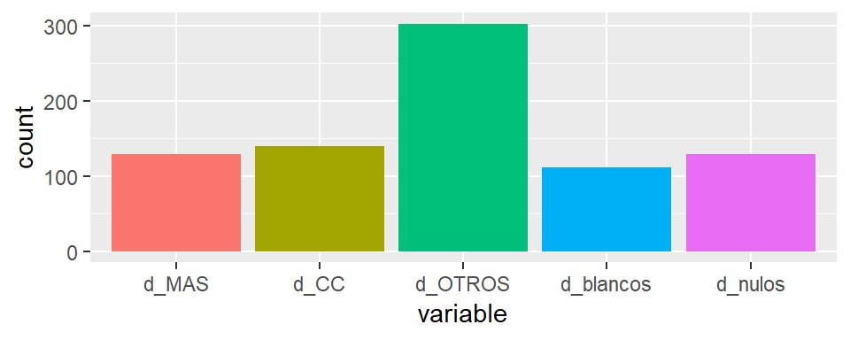

### Dif. Positivas

| d_MAS | d_CC | d_OTROS | d_blancos | d_nulos |
| --- | --- | --- | --- | --- |
| 89 | 101 | 113 | 30 | 82 |

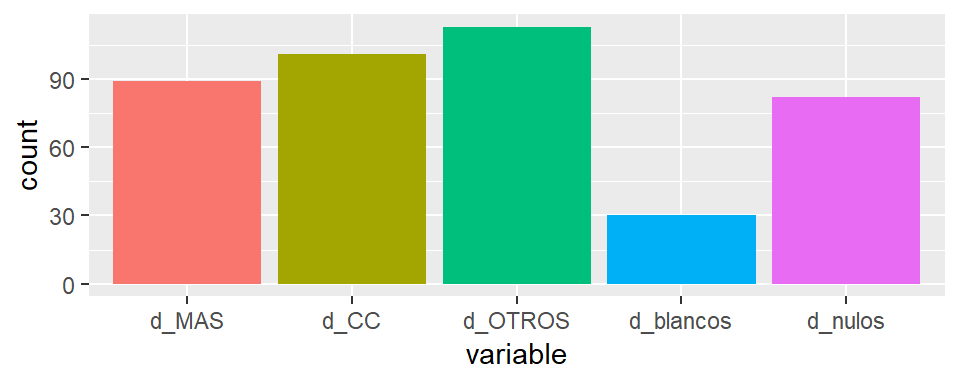

### Dif. negativas

| d_MAS | d_CC | d_OTROS | d_blancos | d_nulos |
| --- | --- | --- | --- | --- |
| 40 | 39 | 189 | 81 | 47 |

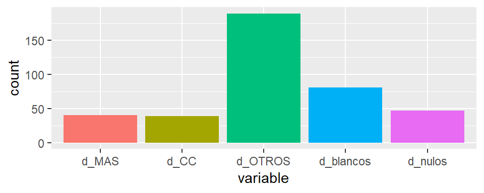

## 2.5 Análisis estadístico

Ahora realizamos un estadistico tomando dos casos catalogados como sigue:

- **NO CEROS** Caso que considerando solo las diferencias distintas de cero por tipo de voto
- **TODA DIF.:** Caso que considera toda la población de actas con diferencias.

### Resumen estadístico

#### NO CEROS

| stats | MAS | CC | OTROS | blancos | nulos |
| --- | --- | --- | --- | --- | --- |
| n | 129.000000 | 140.00000 | 302.000000 | 111.000000 | 129.0000000 |
| min | -125.000000 | -45.00000 | -213.000000 | -71.000000 | -129.0000000 |
| q1 | -1.000000 | -1.00000 | -5.000000 | -18.500000 | -1.0000000 |
| median | 10.000000 | 10.00000 | -1.000000 | -4.000000 | 1.0000000 |
| mean | 20.596899 | 13.59286 | -5.235099 | -9.594595 | -0.0620155 |
| q3 | 10.000000 | 10.00000 | -1.000000 | -4.000000 | 1.0000000 |
| max | 213.000000 | 150.00000 | 64.000000 | 86.000000 | 15.0000000 |
| sd | 44.111103 | 24.28663 | 26.076957 | 22.475190 | 12.2975810 |
| cv | 2.141638 | 1.78672 | 4.981177 | 2.342485 | 198.2984940 |

#### TODA DIF.

| stats | MAS | CC | OTROS | blancos | nulos |
| --- | --- | --- | --- | --- | --- |
| n | 537.000000 | 537.000000 | 537.000000 | 537.000000 | 537.00000000 |
| min | -125.000000 | -45.000000 | -213.000000 | -71.000000 | -129.00000000 |
| q1 | 0.000000 | 0.000000 | -1.000000 | 0.000000 | 0.00000000 |
| median | 0.000000 | 0.000000 | 0.000000 | 0.000000 | 0.00000000 |
| mean | 4.947858 | 3.543762 | -2.944134 | -1.983240 | -0.01489758 |
| q3 | 0.000000 | 0.000000 | 0.000000 | 0.000000 | 0.00000000 |
| max | 213.000000 | 150.000000 | 64.000000 | 86.000000 | 15.00000000 |
| sd | 23.286043 | 13.734640 | 19.713637 | 10.899032 | 6.00961307 |
| cv | 4.706287 | 3.875723 | 6.695903 | 5.495568 | 403.39527754 |

### Diagramas de caja

#### NO CEROS

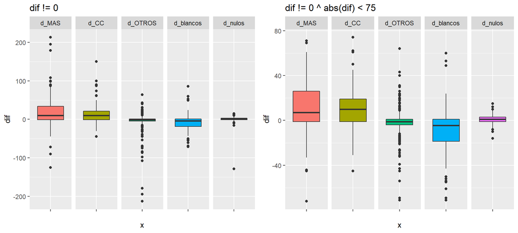

#### TODA DIF.

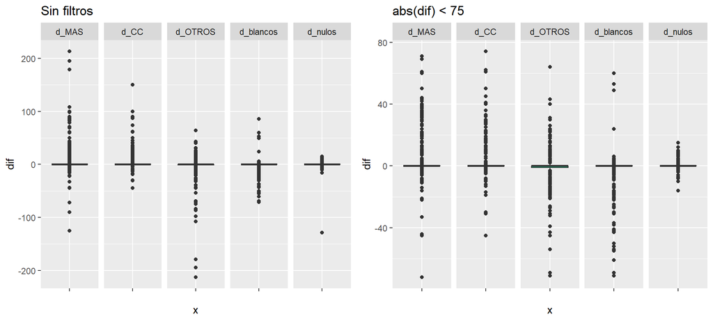

### Histogramas

#### NO CEROS

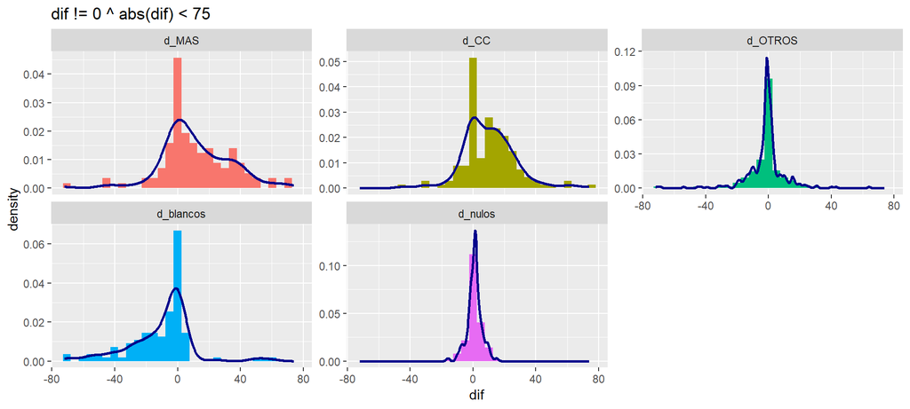

#### TODA DIF.

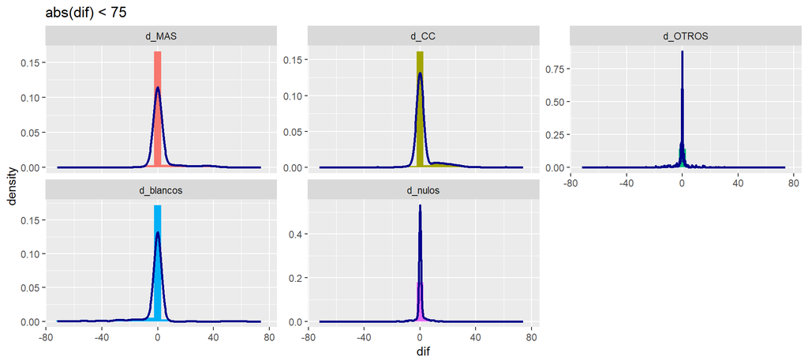

## 2.6 Análisis de sesgo

### 2.6.1 Distribución de signos

| tipo | n_dif | pos_dif | neg_dif | pos_frec | neg_frec |
| --- | --- | --- | --- | --- | --- |
| d_MAS | 129 | 89 | 40 | 0.6899225 | 0.3100775 |
| d_CC | 140 | 101 | 39 | 0.7214286 | 0.2785714 |
| d_OTROS | 302 | 113 | 189 | 0.3741722 | 0.6258278 |
| d_blancos | 111 | 30 | 81 | 0.2702703 | 0.7297297 |
| d_nulos | 129 | 82 | 47 | 0.6356589 | 0.3643411 |

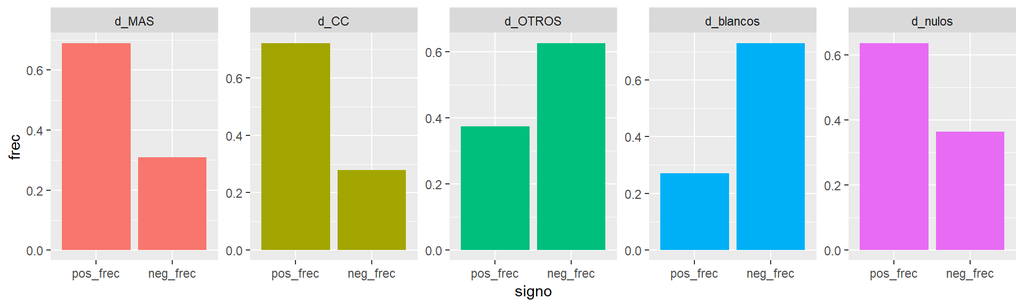

### 2.6.2 Análisis por signo

#### Resumen estadístico

##### Dif. Positivas

| stats | MAS | CC | OTROS | blancos | nulos |
| --- | --- | --- | --- | --- | --- |
| n | 89.000000 | 101.000000 | 113.000000 | 30.000000 | 82.0000000 |
| min | 1.000000 | 1.000000 | 1.000000 | 1.000000 | 1.0000000 |
| q1 | 10.000000 | 10.000000 | 1.000000 | 1.000000 | 1.0000000 |
| median | 24.000000 | 15.000000 | 3.000000 | 1.000000 | 2.0000000 |
| mean | 36.337079 | 21.415842 | 7.469027 | 10.800000 | 3.3902439 |
| q3 | 24.000000 | 15.000000 | 3.000000 | 1.000000 | 2.0000000 |
| max | 213.000000 | 150.000000 | 64.000000 | 86.000000 | 15.0000000 |
| sd | 41.338114 | 23.700324 | 10.009880 | 21.542900 | 3.0581044 |
| cv | 1.137629 | 1.106673 | 1.340185 | 1.994713 | 0.9020308 |

##### Dif. Negativas

| stats | MAS | CC | OTROS | blancos | nulos |
| --- | --- | --- | --- | --- | --- |
| n | 40.00000 | 39.000000 | 189.00000 | 81.000000 | 47.000000 |
| min | -125.00000 | -45.000000 | -213.00000 | -71.000000 | -129.000000 |
| q1 | -11.75000 | -8.000000 | -11.00000 | -26.000000 | -5.000000 |
| median | -3.50000 | -2.000000 | -3.00000 | -12.000000 | -2.000000 |
| mean | -14.42500 | -6.666667 | -12.83069 | -17.148148 | -6.085106 |
| q3 | -3.50000 | -2.000000 | -3.00000 | -12.000000 | -2.000000 |
| max | -1.00000 | -1.000000 | -1.00000 | -1.000000 | -1.000000 |
| sd | 26.58888 | 9.771961 | 29.56408 | 17.679869 | 18.602045 |
| cv | 1.84325 | 1.465794 | 2.30417 | 1.031007 | 3.056979 |

#### Diagramas de caja

##### Dif. Positivas

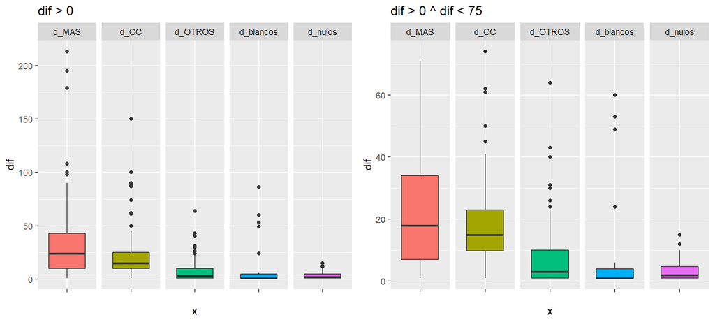

##### Dif. Negativas

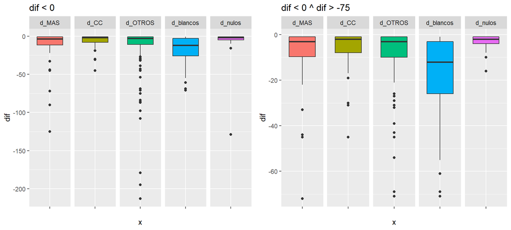

#### Histogramas

##### Dif. Positivas

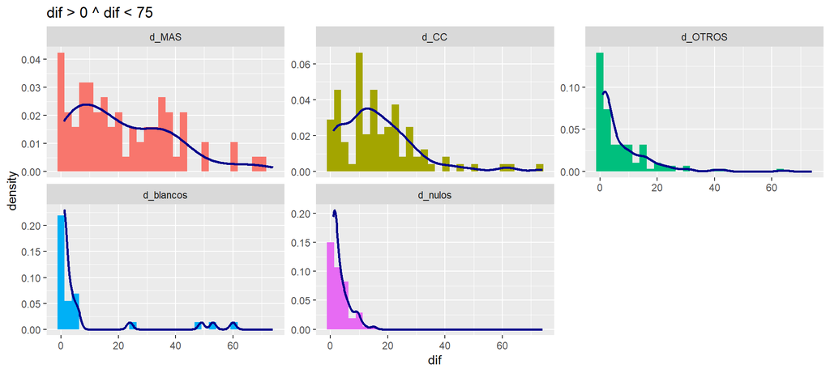

##### Dif. Negativas

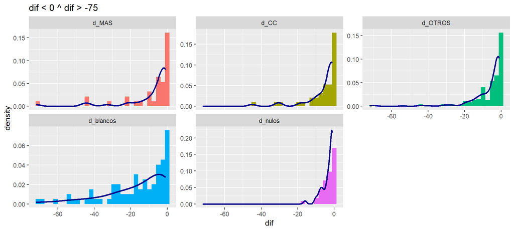

## 2.7 Impacto de diferencias

A continuación se muestra la sumatoria de las diferencias por tipo de voto.

| d_MAS | d_CC | d_OTROS | d_blancos | d_nulos |
| --- | --- | --- | --- | --- |
| 2657 | 1903 | -1581 | -1065 | -8 |

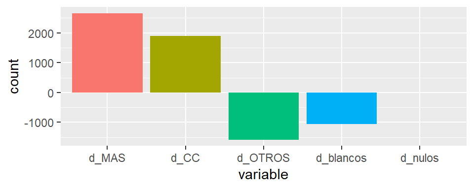

## 2.8 Simulación de escenarios

### Escenario 1

> Mantener las diferencias totales que afectan a los votos de CC y OTROS en los últimos resultados oficiales y omitir el incremento total a los votos del MAS.

| variable | n_oficial | frec_oficial | sim_delta | n_sim | frec_sim |
| --- | --- | --- | --- | --- | --- |
| MAS | 2889074 | 0.4707457 | -2657 | 2886417 | 0.4705164 |
| CC | 2240894 | 0.3651312 | 0 | 2240894 | 0.3652894 |
| OTROS | 1007261 | 0.1641231 | 0 | 1007261 | 0.1641942 |

### Escenario 2

> A nivel de actas, omitir cualquier diferencia positiva para el MAS y OTROS, mientras que para CC omitir cualquier diferencia negativa.

| variable | n_oficial | frec_oficial | sim_delta | n_sim | frec_sim |
| --- | --- | --- | --- | --- | --- |
| MAS | 2889074 | 0.4707457 | -3234 | 2885840 | 0.4705114 |
| CC | 2240894 | 0.3651312 | 260 | 2241154 | 0.3654009 |
| OTROS | 1007261 | 0.1641231 | -844 | 1006417 | 0.1640877 |

# 3 Último TREP vs último oficial

A continuación se realiza un análisis de diferencias en los votos entre los ultimos datos del TREP y el cómputo oficial disponibles en la base de datos.

- *Fecha y hora último TREP:* 2019-10-25 10:13:40
- *Fecha y hora último oficial:* 2019-10-25 07:20:35

## 3.1 Calculo de diferencias

Se calculan las diferencias como sigue: `d_X = X.comp - X.trep`

```
Observations: 34,551
Variables: 16
$ cod_mesa     <chr> "100320112000000101", "100320112000000102", "1003...
$ MAS.comp     <int> 111, 110, 95, 93, 88, 52, 100, 92, 83, 61, 103, 1...
$ CC.comp      <int> 46, 57, 62, 54, 62, 26, 55, 65, 92, 102, 65, 14, ...
$ OTROS.comp   <int> 14, 20, 21, 22, 19, 9, 17, 27, 14, 18, 15, 1, 2, ...
$ blancos.comp <int> 9, 3, 6, 7, 5, 1, 3, 1, 2, 2, 5, 1, 6, 6, 5, 11, ...
$ nulos.comp   <int> 4, 2, 11, 8, 5, 2, 12, 9, 13, 9, 12, 1, 11, 12, 0...
$ MAS.trep     <int> 111, 110, 95, 93, 88, 52, 100, 92, 83, 61, 103, 1...
$ CC.trep      <int> 46, 57, 62, 54, 62, 26, 55, 65, 92, 102, 65, 14, ...
$ OTROS.trep   <int> 14, 20, 21, 22, 19, 9, 17, 27, 14, 18, 15, 1, 2, ...
$ blancos.trep <int> 9, 3, 6, 7, 5, 1, 3, 1, 2, 2, 5, 1, 6, 6, 5, 11, ...
$ nulos.trep   <int> 4, 2, 11, 8, 5, 2, 12, 9, 13, 9, 12, 1, 11, 12, 0...
$ d_MAS        <int> 0, 0, 0, 0, 0, 0, 0, 0, 0, 0, 0, 0, 0, 0, 0, 0, 0...
$ d_CC         <int> 0, 0, 0, 0, 0, 0, 0, 0, 0, 0, 0, 0, 0, 0, 0, 0, 0...
$ d_OTROS      <int> 0, 0, 0, 0, 0, 0, 0, 0, 0, 0, 0, 0, 0, 0, 0, 0, 0...
$ d_blancos    <int> 0, 0, 0, 0, 0, 0, 0, 0, 0, 0, 0, 0, 0, 0, 0, 0, 0...
$ d_nulos      <int> 0, 0, 0, 0, 0, 0, 0, 0, 0, 0, 0, 0, 0, 0, 0, 0, 0...
```

## 3.2 Datos faltantes

Realizando un conteo de datos faltantes en las columnas de votos por partidos, blancos, nulos y diferencias, tenemos lo siguiente.

```
Observations: 1
Variables: 15
$ MAS.comp     <dbl> 0
$ CC.comp      <dbl> 0
$ OTROS.comp   <dbl> 0
$ blancos.comp <dbl> 0
$ nulos.comp   <dbl> 0
$ MAS.trep     <dbl> 1509
$ CC.trep      <dbl> 1509
$ OTROS.trep   <dbl> 1509
$ blancos.trep <dbl> 1509
$ nulos.trep   <dbl> 1509
$ d_MAS        <dbl> 1509
$ d_CC         <dbl> 1509
$ d_OTROS      <dbl> 1509
$ d_blancos    <dbl> 1509
$ d_nulos      <dbl> 1509
```

Luego, dado que los datos faltantes en las diferencias corresponden a faltantes en la base de datos del TREP seguiremos el análisis filtrando todos los faltantes. El extracto de los datos resultantes es el siguiente.

```
Observations: 33,042
Variables: 16
$ cod_mesa     <chr> "100320112000000101", "100320112000000102", "1003...
$ MAS.comp     <int> 111, 110, 95, 93, 88, 52, 100, 92, 83, 61, 103, 1...
$ CC.comp      <int> 46, 57, 62, 54, 62, 26, 55, 65, 92, 102, 65, 14, ...
$ OTROS.comp   <int> 14, 20, 21, 22, 19, 9, 17, 27, 14, 18, 15, 1, 2, ...
$ blancos.comp <int> 9, 3, 6, 7, 5, 1, 3, 1, 2, 2, 5, 1, 6, 6, 5, 11, ...
$ nulos.comp   <int> 4, 2, 11, 8, 5, 2, 12, 9, 13, 9, 12, 1, 11, 12, 0...
$ MAS.trep     <int> 111, 110, 95, 93, 88, 52, 100, 92, 83, 61, 103, 1...
$ CC.trep      <int> 46, 57, 62, 54, 62, 26, 55, 65, 92, 102, 65, 14, ...
$ OTROS.trep   <int> 14, 20, 21, 22, 19, 9, 17, 27, 14, 18, 15, 1, 2, ...
$ blancos.trep <int> 9, 3, 6, 7, 5, 1, 3, 1, 2, 2, 5, 1, 6, 6, 5, 11, ...
$ nulos.trep   <int> 4, 2, 11, 8, 5, 2, 12, 9, 13, 9, 12, 1, 11, 12, 0...
$ d_MAS        <int> 0, 0, 0, 0, 0, 0, 0, 0, 0, 0, 0, 0, 0, 0, 0, 0, 0...
$ d_CC         <int> 0, 0, 0, 0, 0, 0, 0, 0, 0, 0, 0, 0, 0, 0, 0, 0, 0...
$ d_OTROS      <int> 0, 0, 0, 0, 0, 0, 0, 0, 0, 0, 0, 0, 0, 0, 0, 0, 0...
$ d_blancos    <int> 0, 0, 0, 0, 0, 0, 0, 0, 0, 0, 0, 0, 0, 0, 0, 0, 0...
$ d_nulos      <int> 0, 0, 0, 0, 0, 0, 0, 0, 0, 0, 0, 0, 0, 0, 0, 0, 0...
```

## 3.3 Actas con diferencias

Ahora mostramos únicamente las actas con cualquier tipo de diferencia. Este conjunto de datos es el que se considera para el resto del análisis.

| cod_mesa | d_MAS | d_CC | d_OTROS | d_blancos | d_nulos |
| --- | --- | --- | --- | --- | --- |
| 100320112060005403 | 0 | -1 | 0 | 0 | 0 |
| 100320112830000101 | 0 | 0 | 10 | 0 | 0 |
| 100320112830000201 | 0 | -17 | 0 | 0 | 0 |
| 100320112950000101 | 0 | -2 | 0 | 0 | 0 |
| 100320113030000102 | 0 | 0 | 1 | 0 | 0 |
| 100320113180000102 | 0 | 22 | 0 | 0 | 0 |
| 100320113310000214 | -2 | 0 | 0 | 0 | 0 |
| 100320113310000215 | 0 | 33 | -20 | 0 | 0 |
| 100320113360000111 | 0 | 0 | 0 | 0 | -8 |
| 100320113710000107 | 0 | 100 | 0 | 0 | 0 |

[output cut: 702 more lines]

## 3.4 Conteo de diferencias

A continuación contamos el número de actas con diferncias por cada tipo de voto.

### Todas las diferencias

| d_MAS | d_CC | d_OTROS | d_blancos | d_nulos |
| --- | --- | --- | --- | --- |
| 177 | 183 | 399 | 147 | 167 |

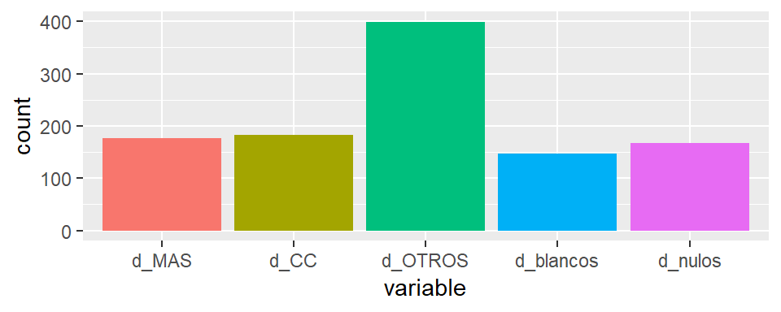

### Dif. Positivas

| d_MAS | d_CC | d_OTROS | d_blancos | d_nulos |
| --- | --- | --- | --- | --- |
| 120 | 130 | 156 | 44 | 105 |

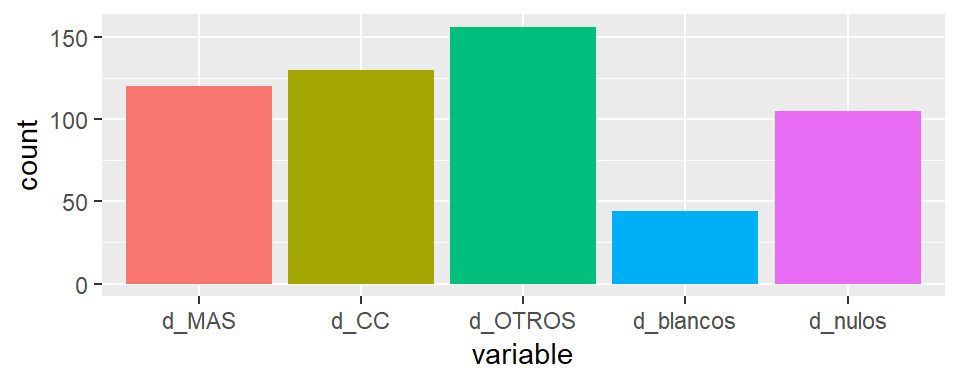

### Dif. negativas

| d_MAS | d_CC | d_OTROS | d_blancos | d_nulos |
| --- | --- | --- | --- | --- |
| 57 | 53 | 243 | 103 | 62 |

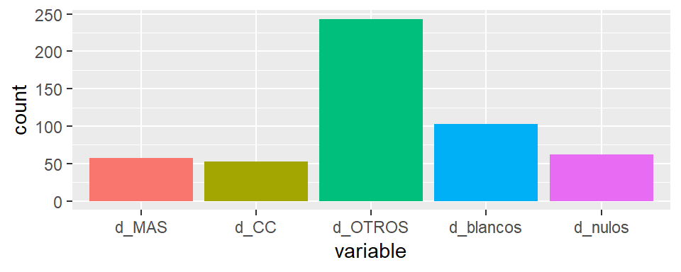

## 3.5 Análisis estadístico

Ahora realizamos un estadistico tomando dos casos catalogados como sigue:

- **NO CEROS** Caso que considerando solo las diferencias distintas de cero por tipo de voto
- **TODA DIF.:** Caso que considera toda la población de actas con diferencias.

### Resumen estadístico

#### NO CEROS

| stats | MAS | CC | OTROS | blancos | nulos |
| --- | --- | --- | --- | --- | --- |
| n | 177.000000 | 183.000000 | 399.000000 | 147.000000 | 167.0000000 |
| min | -125.000000 | -45.000000 | -213.000000 | -131.000000 | -129.0000000 |
| q1 | -1.000000 | -1.000000 | -5.000000 | -18.000000 | -1.0000000 |
| median | 10.000000 | 10.000000 | -1.000000 | -3.000000 | 1.0000000 |
| mean | 20.457627 | 12.535519 | -4.461153 | -10.122449 | 0.3892216 |
| q3 | 10.000000 | 10.000000 | -1.000000 | -3.000000 | 1.0000000 |
| max | 213.000000 | 150.000000 | 108.000000 | 86.000000 | 31.0000000 |
| sd | 44.578451 | 22.061293 | 26.009428 | 24.327925 | 11.3412831 |
| cv | 2.179063 | 1.759903 | 5.830203 | 2.403364 | 29.1383735 |

#### TODA DIF.

| stats | MAS | CC | OTROS | blancos | nulos |
| --- | --- | --- | --- | --- | --- |
| n | 712.000000 | 712.000000 | 712.000000 | 712.000000 | 712.00000000 |
| min | -125.000000 | -45.000000 | -213.000000 | -131.000000 | -129.00000000 |
| q1 | 0.000000 | 0.000000 | -1.000000 | 0.000000 | 0.00000000 |
| median | 0.000000 | 0.000000 | 0.000000 | 0.000000 | 0.00000000 |
| mean | 5.085674 | 3.221910 | -2.500000 | -2.089888 | 0.09129213 |
| q3 | 0.000000 | 0.000000 | 0.000000 | 0.000000 | 0.00000000 |
| max | 213.000000 | 150.000000 | 108.000000 | 86.000000 | 31.00000000 |
| sd | 23.878966 | 12.435201 | 19.585508 | 11.761952 | 5.48249561 |
| cv | 4.695339 | 3.859574 | 7.834203 | 5.628031 | 60.05441344 |

### Diagramas de caja

#### NO CEROS

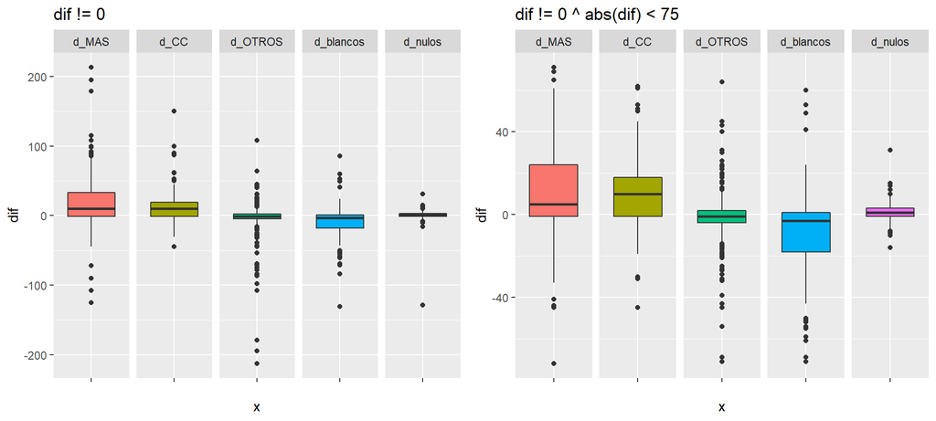

#### TODA DIF.

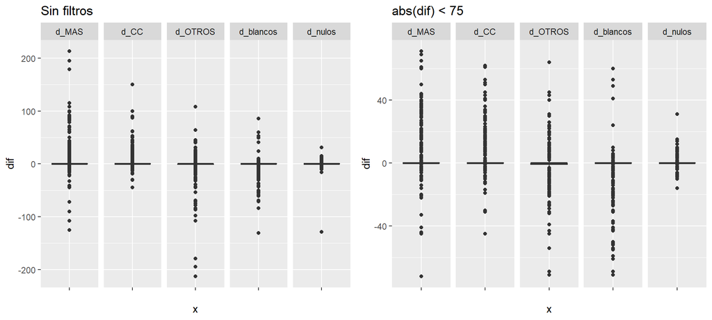

### Histogramas

#### NO CEROS

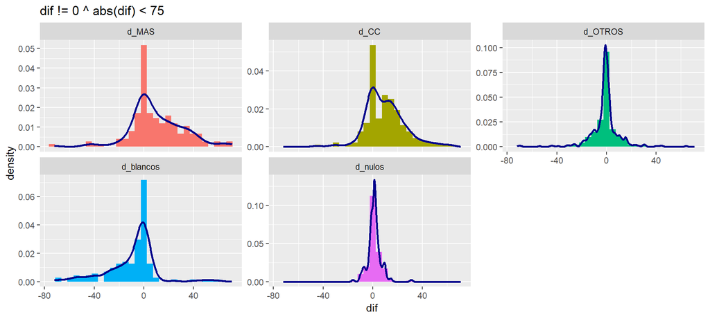

#### TODA DIF.

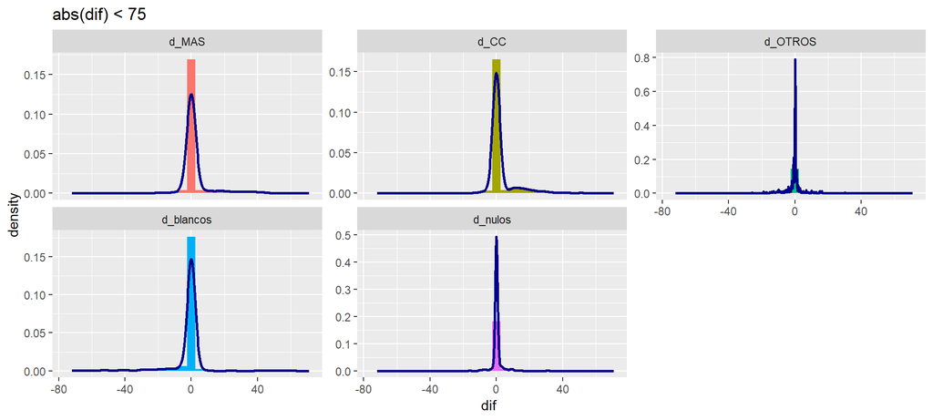

## 3.6 Análisis de sesgo

### 3.6.1 Distribución de signos

| tipo | n_dif | pos_dif | neg_dif | pos_frec | neg_frec |
| --- | --- | --- | --- | --- | --- |
| d_MAS | 177 | 120 | 57 | 0.6779661 | 0.3220339 |
| d_CC | 183 | 130 | 53 | 0.7103825 | 0.2896175 |
| d_OTROS | 399 | 156 | 243 | 0.3909774 | 0.6090226 |
| d_blancos | 147 | 44 | 103 | 0.2993197 | 0.7006803 |
| d_nulos | 167 | 105 | 62 | 0.6287425 | 0.3712575 |

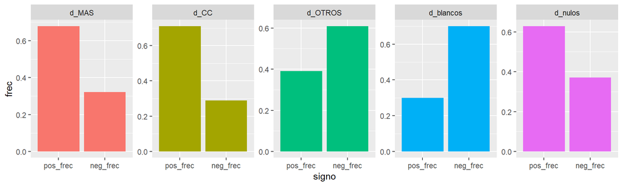

### 3.6.2 Análisis por signo

#### Resumen estadístico

##### Dif. Positivas

| stats | MAS | CC | OTROS | blancos | nulos |
| --- | --- | --- | --- | --- | --- |
| n | 120.000000 | 130.000000 | 156.000000 | 44.000000 | 105.000000 |
| min | 1.000000 | 1.000000 | 1.000000 | 1.000000 | 1.000000 |
| q1 | 9.750000 | 8.250000 | 1.000000 | 1.000000 | 1.000000 |
| median | 23.000000 | 15.000000 | 3.000000 | 1.000000 | 2.000000 |
| mean | 36.883333 | 19.946154 | 7.871795 | 9.000000 | 3.838095 |
| q3 | 23.000000 | 15.000000 | 3.000000 | 1.000000 | 2.000000 |
| max | 213.000000 | 150.000000 | 108.000000 | 86.000000 | 31.000000 |
| sd | 42.057021 | 21.579603 | 12.488817 | 18.837123 | 4.190474 |
| cv | 1.140272 | 1.081893 | 1.586527 | 2.093014 | 1.091811 |

##### Dif. Negativas

| stats | MAS | CC | OTROS | blancos | nulos |
| --- | --- | --- | --- | --- | --- |
| n | 57.000000 | 53.000000 | 243.000000 | 103.000000 | 62.000000 |
| min | -125.000000 | -45.000000 | -213.000000 | -131.000000 | -129.000000 |
| q1 | -11.000000 | -6.000000 | -10.000000 | -26.000000 | -6.000000 |
| median | -4.000000 | -2.000000 | -3.000000 | -11.000000 | -2.000000 |
| mean | -14.122807 | -5.641509 | -12.378601 | -18.291262 | -5.451613 |
| q3 | -4.000000 | -2.000000 | -3.000000 | -11.000000 | -2.000000 |
| max | -1.000000 | -1.000000 | -1.000000 | -1.000000 | -1.000000 |
| sd | 26.298472 | 8.611473 | 29.183600 | 21.735771 | 16.276985 |
| cv | 1.862128 | 1.526448 | 2.357585 | 1.188314 | 2.985719 |

#### Diagramas de caja

##### Dif. Positivas

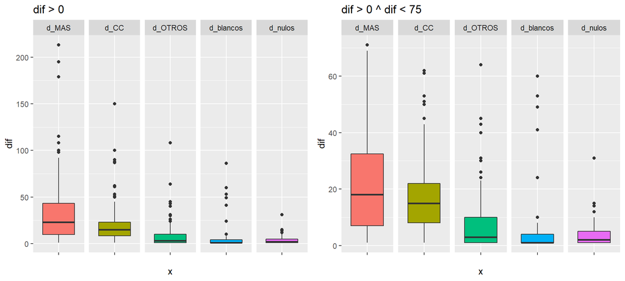

##### Dif. Negativas

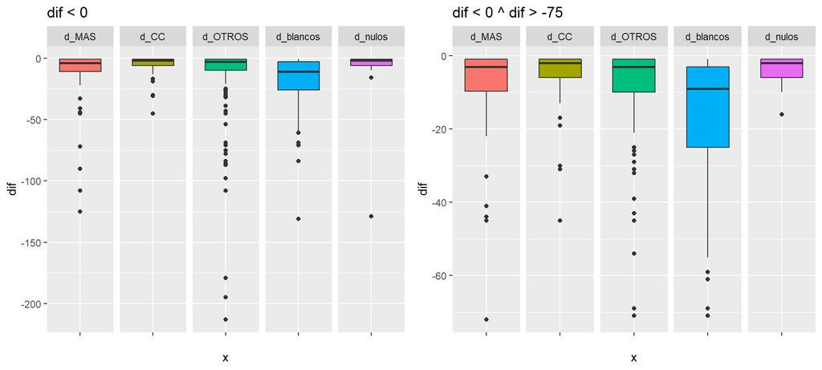

#### Histogramas

##### Dif. Positivas

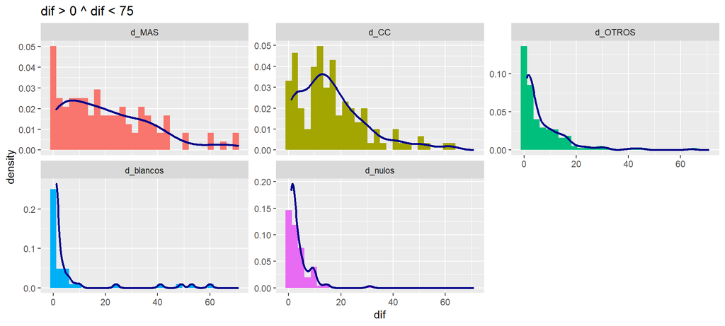

##### Dif. Negativas

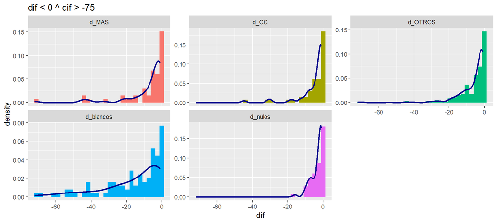

## 3.7 Impacto de diferencias

A continuación se muestra la sumatoria de las diferencias por tipo de voto.

| d_MAS | d_CC | d_OTROS | d_blancos | d_nulos |
| --- | --- | --- | --- | --- |
| 3621 | 2294 | -1780 | -1488 | 65 |

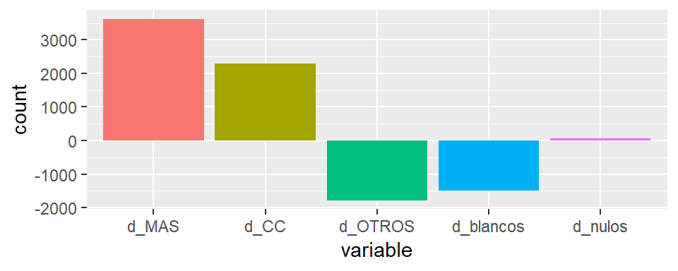

## 3.8 Simulación de escenarios

### Escenario 1

> Mantener las diferencias totales que afectan a los votos de CC y OTROS en los últimos resultados oficiales y omitir el incremento total a los votos del MAS.

| variable | n_oficial | frec_oficial | sim_delta | n_sim | frec_sim |
| --- | --- | --- | --- | --- | --- |
| MAS | 2889074 | 0.4707457 | -3621 | 2885453 | 0.4704332 |
| CC | 2240894 | 0.3651312 | 0 | 2240894 | 0.3653468 |
| OTROS | 1007261 | 0.1641231 | 0 | 1007261 | 0.1642200 |

### Escenario 2

> A nivel de actas, omitir cualquier diferencia positiva para el MAS y OTROS, mientras que para CC omitir cualquier diferencia negativa.

| variable | n_oficial | frec_oficial | sim_delta | n_sim | frec_sim |
| --- | --- | --- | --- | --- | --- |
| MAS | 2889074 | 0.4707457 | -4426 | 2884648 | 0.4704350 |
| CC | 2240894 | 0.3651312 | 299 | 2241193 | 0.3654989 |
| OTROS | 1007261 | 0.1641231 | -1228 | 1006033 | 0.1640662 |